# 4_1_resnet18_PyTorch

[figure not shown]

In this lab, you will use pre-trained models to classify between the negative and positive samples; you will be provided with the dataset object. The particular pre-trained model will be resnet18; you will have three questions:

- change the output layer
- train the model
- identify several misclassified samples

You will take several screenshots of your work and share your notebook.

## Table of Contents

- Download Data
- Imports and Auxiliary Functions
- Dataset Class
- Question 1
- Question 2
- Question 3

Estimated Time Needed: **120 min**

## Download Data

Download the dataset and unzip the files in your data directory, unlike the other labs, all the data will be deleted after you close the lab, this may take some time:

```python
!wget https://s3-api.us-geo.objectstorage.softlayer.net/cf-courses-data/CognitiveClass/DL0321EN/data/images/Positive_tensors.zip
!unzip -q Positive_tensors.zip
!wget https://s3-api.us-geo.objectstorage.softlayer.net/cf-courses-data/CognitiveClass/DL0321EN/data/images/Negative_tensors.zip
!unzip -q Negative_tensors.zip
```

```
--2023-08-24 19:21:29--  https://s3-api.us-geo.objectstorage.softlayer.net/cf-courses-data/CognitiveClass/DL0321EN/data/images/Positive_tensors.zip
Resolving s3-api.us-geo.objectstorage.softlayer.net (s3-api.us-geo.objectstorage.softlayer.net)... 67.228.254.196
Connecting to s3-api.us-geo.objectstorage.softlayer.net (s3-api.us-geo.objectstorage.softlayer.net)|67.228.254.196|:443... connected.
HTTP request sent, awaiting response... 200 OK
Length: 2598656062 (2.4G) [application/zip]
Saving to: ‘Positive_tensors.zip’

Positive_tensors.zi 100%[===================>]   2.42G  37.6MB/s    in 76s

2023-08-24 19:22:45 (32.8 MB/s) - ‘Positive_tensors.zip’ saved [2598656062/2598656062]

--2023-08-24 19:25:24--  https://s3-api.us-geo.objectstorage.softlayer.net/cf-courses-data/CognitiveClass/DL0321EN/data/images/Negative_tensors.zip
Resolving s3-api.us-geo.objectstorage.softlayer.net (s3-api.us-geo.objectstorage.softlayer.net)... 67.228.254.196
Connecting to s3-api.us-geo.objectstorage.softlayer.net (s3-api.us-geo.objectstorage.softlayer.net)|67.228.254.196|:443... connected.
HTTP request sent, awaiting response... 200 OK
Length: 2111408108 (2.0G) [application/zip]
Saving to: ‘Negative_tensors.zip’

Negative_tensors.zi 100%[===================>]   1.97G  32.6MB/s    in 64s

2023-08-24 19:26:29 (31.4 MB/s) - ‘Negative_tensors.zip’ saved [2111408108/2111408108]
```

We will install torchvision:

```python
!pip install torchvision
```

## Imports and Auxiliary Functions

The following are the libraries we are going to use for this lab. The `torch.manual_seed()` is for forcing the random function to give the same number every time we try to recompile it.

```python
# These are the libraries will be used for this lab.
import torchvision.models as models
from PIL import Image
import pandas
from torchvision import transforms
import torch.nn as nn
import time
import torch
import matplotlib.pylab as plt
import numpy as np
from torch.utils.data import Dataset, DataLoader
import h5py
import os
import glob
torch.manual_seed(0)
```

```
<torch._C.Generator at 0x78aca3326730>
```

```python
from matplotlib.pyplot import imshow
import matplotlib.pylab as plt
from PIL import Image
import pandas as pd
import os
```

## Dataset Class

This dataset class is essentially the same dataset you build in the previous section, but to speed things up, we are going to use tensors instead of jpeg images. Therefor for each iteration, you will skip the reshape step, conversion step to tensors and normalization step.

```python
# Create your own dataset object
class Dataset(Dataset):

    # Constructor
    def __init__(self,transform=None,train=True):
        positive_file_path="Positive_tensors"
        negative_file_path="Negative_tensors"
        positive_files=[os.path.join(positive_file_path,file) for file in os.listdir(positive_file_path) if file.endswith(".pt")]
        negative_files=[os.path.join(negative_file_path,file) for file in os.listdir(negative_file_path) if file.endswith(".pt")]
        number_of_samples=len(positive_files)+len(negative_files)
        self.all_files=[None]*number_of_samples
        self.all_files[::2]=positive_files
        self.all_files[1::2]=negative_files
        # The transform is goint to be used on image
        self.transform = transform
        #torch.LongTensor
        self.Y=torch.zeros([number_of_samples]).type(torch.LongTensor)
        self.Y[::2]=1
        self.Y[1::2]=0

        if train:
            self.all_files=self.all_files[0:30000]
            self.Y=self.Y[0:30000]
            self.len=len(self.all_files)
        else:
            self.all_files=self.all_files[30000:]
            self.Y=self.Y[30000:]
            self.len=len(self.all_files)

    # Get the length
    def __len__(self):
        return self.len

    # Getter
    def __getitem__(self, idx):

        image=torch.load(self.all_files[idx])
        y=self.Y[idx]

        # If there is any transform method, apply it onto the image
        if self.transform:
            image = self.transform(image)

        return image, y

print("done")
```

```
done
```

We create two dataset objects, one for the training data and one for the validation data.

```python
train_dataset = Dataset(train=True)
validation_dataset = Dataset(train=False)
print("done")
```

```
done
```

## Question 1

**Prepare a pre-trained resnet18 model :**

**Step 1**: Load the pre-trained model `resnet18` Set the parameter `pretrained` to true:

```python
# Step 1: Load the pre-trained model resnet18

# Type your code here
model = models.resnet18(pretrained=True)
```

**Step 2**: Set the attribute `requires_grad` to `False`. As a result, the parameters will not be affected by training.

```python
# Step 2: Set the parameter cannot be trained for the pre-trained model

# Type your code here
model.requires_grad_(False)
```

```
ResNet(
  (conv1): Conv2d(3, 64, kernel_size=(7, 7), stride=(2, 2), padding=(3, 3), bias=False)
  (bn1): BatchNorm2d(64, eps=1e-05, momentum=0.1, affine=True, track_running_stats=True)
  (relu): ReLU(inplace=True)
  (maxpool): MaxPool2d(kernel_size=3, stride=2, padding=1, dilation=1, ceil_mode=False)
  (layer1): Sequential(
    (0): BasicBlock(
      (conv1): Conv2d(64, 64, kernel_size=(3, 3), stride=(1, 1), padding=(1, 1), bias=False)
      (bn1): BatchNorm2d(64, eps=1e-05, momentum=0.1, affine=True, track_running_stats=True)
      (relu): ReLU(inplace=True)
      (conv2): Conv2d(64, 64, kernel_size=(3, 3), stride=(1, 1), padding=(1, 1), bias=False)
      (bn2): BatchNorm2d(64, eps=1e-05, momentum=0.1, affine=True, track_running_stats=True)
    )
    (1): BasicBlock(
      (conv1): Conv2d(64, 64, kernel_size=(3, 3), stride=(1, 1), padding=(1, 1), bias=False)
      (bn1): BatchNorm2d(64, eps=1e-05, momentum=0.1, affine=True, track_running_stats=True)
      (relu): ReLU(inplace=True)
      (conv2): Conv2d(64, 64, kernel_size=(3, 3), stride=(1, 1), padding=(1, 1), bias=False)
      (bn2): BatchNorm2d(64, eps=1e-05, momentum=0.1, affine=True, track_running_stats=True)
    )
  )
  (layer2): Sequential(
    (0): BasicBlock(
      (conv1): Conv2d(64, 128, kernel_size=(3, 3), stride=(2, 2), padding=(1, 1), bias=False)
      (bn1): BatchNorm2d(128, eps=1e-05, momentum=0.1, affine=True, track_running_stats=True)
      (relu): ReLU(inplace=True)
      (conv2): Conv2d(128, 128, kernel_size=(3, 3), stride=(1, 1), padding=(1, 1), bias=False)
      (bn2): BatchNorm2d(128, eps=1e-05, momentum=0.1, affine=True, track_running_stats=True)
      (downsample): Sequential(
        (0): Conv2d(64, 128, kernel_size=(1, 1), stride=(2, 2), bias=False)
        (1): BatchNorm2d(128, eps=1e-05, momentum=0.1, affine=True, track_running_stats=True)
      )
    )
    (1): BasicBlock(
      (conv1): Conv2d(128, 128, kernel_size=(3, 3), stride=(1, 1), padding=(1, 1), bias=False)
      (bn1): BatchNorm2d(128, eps=1e-05, momentum=0.1, affine=True, track_running_stats=True)
      (relu): ReLU(inplace=True)
      (conv2): Conv2d(128, 128, kernel_size=(3, 3), stride=(1, 1), padding=(1, 1), bias=False)
      (bn2): BatchNorm2d(128, eps=1e-05, momentum=0.1, affine=True, track_running_stats=True)
    )
```

[output cut: 29 more lines]

```
        (0): Conv2d(256, 512, kernel_size=(1, 1), stride=(2, 2), bias=False)
        (1): BatchNorm2d(512, eps=1e-05, momentum=0.1, affine=True, track_running_stats=True)
      )
    )
    (1): BasicBlock(
      (conv1): Conv2d(512, 512, kernel_size=(3, 3), stride=(1, 1), padding=(1, 1), bias=False)
      (bn1): BatchNorm2d(512, eps=1e-05, momentum=0.1, affine=True, track_running_stats=True)
      (relu): ReLU(inplace=True)
      (conv2): Conv2d(512, 512, kernel_size=(3, 3), stride=(1, 1), padding=(1, 1), bias=False)
      (bn2): BatchNorm2d(512, eps=1e-05, momentum=0.1, affine=True, track_running_stats=True)
    )
  )
  (avgpool): AdaptiveAvgPool2d(output_size=(1, 1))
  (fc): Linear(in_features=512, out_features=1000, bias=True)
)
```

`resnet18` is used to classify 1000 different objects; as a result, the last layer has 1000 outputs. The 512 inputs come from the fact that the previously hidden layer has 512 outputs.

**Step 3**: Replace the output layer `model.fc` of the neural network with a `nn.Linear` object, to classify 2 different classes. For the parameters `in_features` remember the last hidden layer has 512 neurons.

```python
model.fc = nn.Linear(512, 2)
```

Print out the model in order to show whether you get the correct answer.  
**(Your peer reviewer is going to mark based on what you print here.)**

```python
print(model)
```

```
ResNet(
  (conv1): Conv2d(3, 64, kernel_size=(7, 7), stride=(2, 2), padding=(3, 3), bias=False)
  (bn1): BatchNorm2d(64, eps=1e-05, momentum=0.1, affine=True, track_running_stats=True)
  (relu): ReLU(inplace=True)
  (maxpool): MaxPool2d(kernel_size=3, stride=2, padding=1, dilation=1, ceil_mode=False)
  (layer1): Sequential(
    (0): BasicBlock(
      (conv1): Conv2d(64, 64, kernel_size=(3, 3), stride=(1, 1), padding=(1, 1), bias=False)
      (bn1): BatchNorm2d(64, eps=1e-05, momentum=0.1, affine=True, track_running_stats=True)
      (relu): ReLU(inplace=True)
      (conv2): Conv2d(64, 64, kernel_size=(3, 3), stride=(1, 1), padding=(1, 1), bias=False)
      (bn2): BatchNorm2d(64, eps=1e-05, momentum=0.1, affine=True, track_running_stats=True)
    )
    (1): BasicBlock(
      (conv1): Conv2d(64, 64, kernel_size=(3, 3), stride=(1, 1), padding=(1, 1), bias=False)
      (bn1): BatchNorm2d(64, eps=1e-05, momentum=0.1, affine=True, track_running_stats=True)
      (relu): ReLU(inplace=True)
      (conv2): Conv2d(64, 64, kernel_size=(3, 3), stride=(1, 1), padding=(1, 1), bias=False)
      (bn2): BatchNorm2d(64, eps=1e-05, momentum=0.1, affine=True, track_running_stats=True)
    )
  )
  (layer2): Sequential(
    (0): BasicBlock(
      (conv1): Conv2d(64, 128, kernel_size=(3, 3), stride=(2, 2), padding=(1, 1), bias=False)
      (bn1): BatchNorm2d(128, eps=1e-05, momentum=0.1, affine=True, track_running_stats=True)
      (relu): ReLU(inplace=True)
      (conv2): Conv2d(128, 128, kernel_size=(3, 3), stride=(1, 1), padding=(1, 1), bias=False)
      (bn2): BatchNorm2d(128, eps=1e-05, momentum=0.1, affine=True, track_running_stats=True)
      (downsample): Sequential(
        (0): Conv2d(64, 128, kernel_size=(1, 1), stride=(2, 2), bias=False)
        (1): BatchNorm2d(128, eps=1e-05, momentum=0.1, affine=True, track_running_stats=True)
      )
    )
    (1): BasicBlock(
      (conv1): Conv2d(128, 128, kernel_size=(3, 3), stride=(1, 1), padding=(1, 1), bias=False)
      (bn1): BatchNorm2d(128, eps=1e-05, momentum=0.1, affine=True, track_running_stats=True)
      (relu): ReLU(inplace=True)
      (conv2): Conv2d(128, 128, kernel_size=(3, 3), stride=(1, 1), padding=(1, 1), bias=False)
      (bn2): BatchNorm2d(128, eps=1e-05, momentum=0.1, affine=True, track_running_stats=True)
    )
```

[output cut: 29 more lines]

```
        (0): Conv2d(256, 512, kernel_size=(1, 1), stride=(2, 2), bias=False)
        (1): BatchNorm2d(512, eps=1e-05, momentum=0.1, affine=True, track_running_stats=True)
      )
    )
    (1): BasicBlock(
      (conv1): Conv2d(512, 512, kernel_size=(3, 3), stride=(1, 1), padding=(1, 1), bias=False)
      (bn1): BatchNorm2d(512, eps=1e-05, momentum=0.1, affine=True, track_running_stats=True)
      (relu): ReLU(inplace=True)
      (conv2): Conv2d(512, 512, kernel_size=(3, 3), stride=(1, 1), padding=(1, 1), bias=False)
      (bn2): BatchNorm2d(512, eps=1e-05, momentum=0.1, affine=True, track_running_stats=True)
    )
  )
  (avgpool): AdaptiveAvgPool2d(output_size=(1, 1))
  (fc): Linear(in_features=512, out_features=2, bias=True)
)
```

## Question 2: Train the Model

In this question you will train your, model:

**Step 1**: Create a cross entropy criterion function

```python
# Step 1: Create the loss function

# Type your code here
criterion = nn.CrossEntropyLoss()
```

**Step 2**: Create a training loader and validation loader object, the batch size should have 100 samples each.

```python
train_loader = torch.utils.data.DataLoader(dataset=train_dataset, batch_size=100)
validation_loader = torch.utils.data.DataLoader(dataset=validation_dataset, batch_size=100)
```

**Step 3**: Use the following optimizer to minimize the loss

```python
optimizer = torch.optim.Adam([parameters for parameters in model.parameters() if parameters.requires_grad], lr=0.001)
```

**Complete the following code to calculate the accuracy on the validation data for one epoch; this should take about 45 minutes. Make sure you calculate the accuracy on the validation data.**

```python
n_epochs=2
loss_list=[]
accuracy_list=[]
correct=0
N_test=len(validation_dataset)
N_train=len(train_dataset)
start_time = time.time()

Loss=0
start_time = time.time()
for epoch in range(n_epochs):
    count_train = 0
    for x, y in train_loader:
        count_train += 1
        if count_train % 10 == 0:
            print(f"Training model... ({count_train} / {len(train_loader)})")
        # set model to train
        model.train()
        # clear gradient
        optimizer.zero_grad()
        # make a prediction
        z = model(x)
        # calculate loss
        loss = criterion(z, y)
        # calculate gradients of parameters
        loss.backward()
        # update parameters
        optimizer.step()
        loss_list.append(loss.data)
    correct=0
    count_val = 0
    for x_test, y_test in validation_loader:
        count_val += 1
        if count_val % 10 == 0:
            print(f"Validating model... ({count_val} / {len(validation_loader)})")
        # set model to eval
        model.eval()
        # make a prediction
        z = model(x_test)
        # find max
        _, yhat = torch.max(z.data, 1)
        # Calculate misclassified samples in mini-batch
        correct += (yhat == y_test).sum().item()
    accuracy=correct/N_test
```

```
Training model... (10 / 300)
Training model... (20 / 300)
Training model... (30 / 300)
Training model... (40 / 300)
Training model... (50 / 300)
Training model... (60 / 300)
Training model... (70 / 300)
Training model... (80 / 300)
Training model... (90 / 300)
Training model... (100 / 300)
Training model... (110 / 300)
Training model... (120 / 300)
Training model... (130 / 300)
Training model... (140 / 300)
Training model... (150 / 300)
Training model... (160 / 300)
Training model... (170 / 300)
Training model... (180 / 300)
Training model... (190 / 300)
Training model... (200 / 300)
Training model... (210 / 300)
Training model... (220 / 300)
Training model... (230 / 300)
Training model... (240 / 300)
Training model... (250 / 300)
Training model... (260 / 300)
Training model... (270 / 300)
Training model... (280 / 300)
Training model... (290 / 300)
Training model... (300 / 300)
Validating model... (10 / 100)
Validating model... (20 / 100)
Validating model... (30 / 100)
Validating model... (40 / 100)
Validating model... (50 / 100)
Validating model... (60 / 100)
Validating model... (70 / 100)
Validating model... (80 / 100)
Validating model... (90 / 100)
Validating model... (100 / 100)
```

[output cut: 25 more lines]

```
Training model... (260 / 300)
Training model... (270 / 300)
Training model... (280 / 300)
Training model... (290 / 300)
Training model... (300 / 300)
Validating model... (10 / 100)
Validating model... (20 / 100)
Validating model... (30 / 100)
Validating model... (40 / 100)
Validating model... (50 / 100)
Validating model... (60 / 100)
Validating model... (70 / 100)
Validating model... (80 / 100)
Validating model... (90 / 100)
Validating model... (100 / 100)
```

**Print out the Accuracy and plot the loss stored in the list `loss_list` for every iteration and take a screen shot.**

```python
accuracy
```

```
0.9962
```

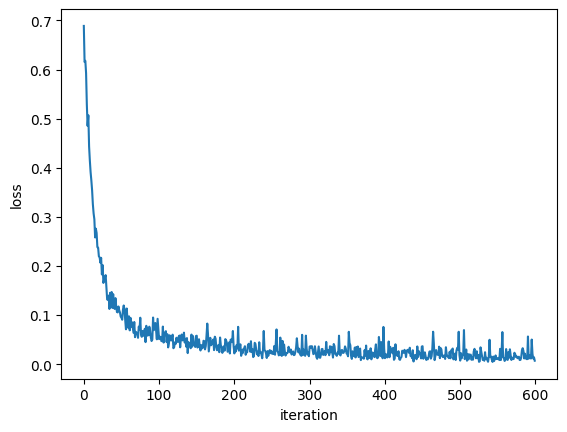

```python
plt.plot(loss_list)
plt.xlabel("iteration")
plt.ylabel("loss")
plt.show()
```

## Question 3:Find the misclassified samples

**Identify the first four misclassified samples using the validation data:**

```python
validation_loader = torch.utils.data.DataLoader(dataset=validation_dataset, batch_size=1)
misclassified = 0
count = 0
for x, y in validation_loader:
    z = model(x)
    _, yhat = torch.max(z, 1)
    count += 1
    if yhat==y: continue
    misclassified += 1
    prediction = 'Negative' if yhat[0]==0 else 'Positive'
    truth = 'Negative' if y[0]==0 else 'Positive'
    print(f"Misclassified sample #{count-1}: predicted {prediction}, actual {truth}")
    if misclassified>=4: break
```

```
Misclassified sample #327: predicted Positive, actual Negative
Misclassified sample #719: predicted Positive, actual Negative
Misclassified sample #760: predicted Negative, actual Positive
Misclassified sample #821: predicted Positive, actual Negative
```

CLICK HERE Click here to see how to share your notebook.

## About the Authors:

Joseph Santarcangelo has a PhD in Electrical Engineering, his research focused on using machine learning, signal processing, and computer vision to determine how videos impact human cognition. Joseph has been working for IBM since he completed his PhD.

## Change Log

| Date (YYYY-MM-DD) | Version | Changed By | Change Description |
| --- | --- | --- | --- |
| 2020-09-21 | 2.0 | Shubham | Migrated Lab to Markdown and added to course repo in GitLab |

Copyright © 2018 cognitiveclass.ai. This notebook and its source code are released under the terms of the MIT License.